# Chapter 3 ~ Logistic Regression

Let’s start working by opening the dataset with read.table -command and taking a look at the structure of it. The data has been previously merged from two different files.

```r
alc <- read.table(file= "http://s3.amazonaws.com/assets.datacamp.com/production/course_2218/datasets/alc.txt ", header=T, sep=",")

colnames(alc)
```

```
##  [1] "school"     "sex"        "age"        "address"    "famsize"
##  [6] "Pstatus"    "Medu"       "Fedu"       "Mjob"       "Fjob"
## [11] "reason"     "nursery"    "internet"   "guardian"   "traveltime"
## [16] "studytime"  "failures"   "schoolsup"  "famsup"     "paid"
## [21] "activities" "higher"     "romantic"   "famrel"     "freetime"
## [26] "goout"      "Dalc"       "Walc"       "health"     "absences"
## [31] "G1"         "G2"         "G3"         "alc_use"    "high_use"
```

The data addresses alcohol consumptions among 15 to 22 aged students in math and portuguese language courses. The 33 variables that can be seen upon include questions about studying times, grades, other topics related to school, backround information about the person, his/her family and social status and finally alcohol spending on week days and weekends. There are two additional variables; “alc_use” and “high_use”. Alc_use tells the average of week day and weekend alcohol consumption and high_use is a logical vector, which is true if alc_use is higher than two.

At this chapter, the purpose is to study the relationship between four picked variables and the variable “hig_use”. We now choose next four variables;

- “goout” Going out with friends (scale numeric: 1 - very low ; 5 - very high)
- “famrel” Quality of family relationships (numeric: 1 - very bad ; 5 - excellent)
- “studytime” Weekly studytime in hours (numeric: 1 - <2 hours; 2 - 2 to 5 hours; 3 - 5 to 10 hours; 4 - >10 hours)
- “sex” binary: ‘F’ - female or ‘M’ - male

to explain higher use of alcohol in the study group. One could predict that going out with friends will be the best to explain alcohol consumption. Family relationships could have a small effect as well as the studytime. Maybe, if it wasn’t for high_use that we are trying to explain here, it probably would have been better trying to explain high_use’s effect on the weekly studying time than other way around. However, sex could have a greater explanation power on high_use (than “famrel” or “studytime”), but not as great as the first variable “goout”.

First we study the relationships between single variables by crosstabulation and grahps. It seems that among those with high value on “goout” is also more true-values of high_use, which is not suprising. All in all the graphics do not show that mindblowing results and maybe one finds the crosstabulation being more appealing for interpretation.

```r
alc %>% group_by(high_use, sex) %>% summarise(count = n(), mean_goout=mean(goout), mean_famrel=mean(famrel), mean_studytime=mean(studytime))
```

```
## Source: local data frame [4 x 6]
## Groups: high_use [?]
##
##   high_use    sex count mean_goout mean_famrel mean_studytime
##      (lgl) (fctr) (int)      (dbl)       (dbl)          (dbl)
## 1    FALSE      F   157   2.955414    3.917197       2.343949
## 2    FALSE      M   113   2.716814    4.150442       1.876106
## 3     TRUE      F    41   3.390244    3.731707       2.000000
## 4     TRUE      M    71   3.929577    3.774648       1.619718
```

We see that when high_use is true, the mean of going out with friends is greater for both sex. For other two variables we have rather sex divided differencies than a division for false and true high_use values. Here are also bar plots about relationships between the result and explanatory variables, that are merged into one picture with help of this page.

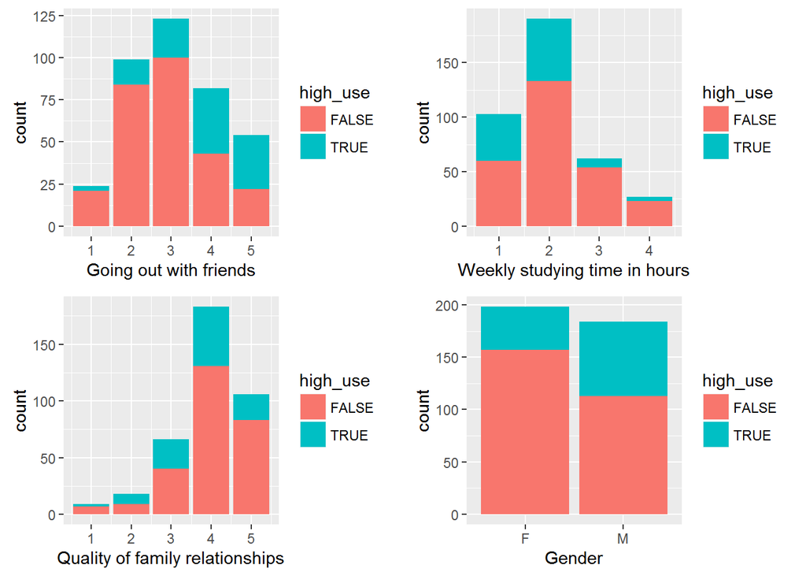

```r
g1 <- ggplot(alc, aes(x = goout, fill=high_use)) + geom_bar() + xlab("Going out with friends")

g2 <- ggplot(alc, aes(x = famrel, fill=high_use)) + geom_bar() + xlab("Quality of family relationships")

g3 <- ggplot(alc, aes(x = studytime, fill=high_use)) + geom_bar() + xlab("Weekly studying time in hours")

g4 <- ggplot(alc, aes(x = sex, fill=high_use)) + geom_bar() + xlab("Gender")

multiplot(g1, g2, g3, g4, cols=2)
```

Next we will fit a model with these four variables as explanatory and high_use as the result variable.

```r
Log <- glm(high_use ~ goout + famrel + studytime + sex, data = alc, family = "binomial")

summary(Log)
```

```
##
## Call:
## glm(formula = high_use ~ goout + famrel + studytime + sex, family = "binomial",
##     data = alc)
##
## Deviance Residuals:
##     Min       1Q   Median       3Q      Max
## -1.5928  -0.7494  -0.4919   0.8250   2.7080
##
## Coefficients:
##             Estimate Std. Error z value Pr(>|z|)
## (Intercept)  -1.2112     0.7142  -1.696  0.08991 .
## goout         0.7947     0.1218   6.523 6.89e-11 ***
## famrel       -0.4496     0.1379  -3.260  0.00111 **
## studytime    -0.4752     0.1703  -2.790  0.00527 **
## sexM          0.7593     0.2655   2.860  0.00424 **
## ---
## Signif. codes:  0 '***' 0.001 '**' 0.01 '*' 0.05 '.' 0.1 ' ' 1
##
## (Dispersion parameter for binomial family taken to be 1)
##
##     Null deviance: 462.21  on 381  degrees of freedom
## Residual deviance: 379.27  on 377  degrees of freedom
## AIC: 389.27
##
## Number of Fisher Scoring iterations: 4
```

In the results we see that the explanatory variables aren’t that bad in p-value sense, at least. “goout” has at least a very significant p-value; it is basically zero. Also the other three variables have significant enough p-values; 0.001, 0.005 and 0.004.

Interpreting the estimated coefficients is a bit more complex than in linear regression, because now we have a binary outcome variable. The backroud for this is that, to make our model linear, we need to fix it with some calculation. The logistic regression model is based on a logistic function and thus the result variable values are actually values of the link function. That is basically the log of odds. This results in the fact that coefficient values can be interpret as odds ratios when we take the exponential of a single coefficient.

In general R is now showing us the value of coeff. when we compare it to a controll group that R has selected automaticly and the real value of this coeff. is calculated: intercept - the value.

After the model has been fit we can calculate OR-values and confidence intervals for the parameters.

```r
OR <- coef(Log) %>% exp

CI <- confint(Log) %>% exp

cbind(OR, CI)
```

```
##                    OR      2.5 %    97.5 %
## (Intercept) 0.2978484 0.07158146 1.1881189
## goout       2.2138196 1.75581193 2.8339395
## famrel      0.6378742 0.48488876 0.8343189
## studytime   0.6217330 0.44091699 0.8617913
## sexM        2.1368457 1.27450527 3.6171734
```

Finally, after all fitting and counting it is possible to make some predictions with the fitted model.

```r
# predict() the probability of high_use
probabilities <- predict(Log, type = "response")

# add the predicted probabilities to 'alc'
alc <- mutate(alc, probability = probabilities)

# use the probabilities to make a prediction of high_use
alc <- mutate(alc, prediction = probabilities > 0.5)


table(high_use = alc$high_use, prediction = alc$prediction) %>% prop.table %>% addmargins
```

```
##         prediction
## high_use      FALSE       TRUE        Sum
##    FALSE 0.63874346 0.06806283 0.70680628
##    TRUE  0.17277487 0.12041885 0.29319372
##    Sum   0.81151832 0.18848168 1.00000000
```

```r
# define a loss function (mean prediction error)
loss_func <- function(class, prob) {
  n_wrong <- abs(class - prob) > 0.5
  mean(n_wrong)
}

# call loss_func to compute the average number of wrong predictions in the (training) data
loss_func(class = alc$high_use, prob = alc$probabilities)
```

```
## [1] NaN
```